# Final Project

Katherine Zen, Zhiyue Gao, Weiyi Qin

# Analysis of crime record of San Fransico

### Motivation:

Monitoring and tracking cirme records of cities seems fairly important, it not only implicitly states how crimes are committed but also gives the authorities a better way to analyze the features of crimes across cities and enforce more security to reduce the crimes efficiently. Therefore, we are giving this turorial of how to do the analysis of a San Fransico Crime Data Set in a way of data science that we learned in class of CMSC320.

### Introduction

In this project, we basing on the [dataset](https://www.kaggle.com/roshansharma/sanfranciso-crime-dataset/data#) on the Kaggle provided by Roshan Sharma to give a tutorial how to do the anaylsis. Generally we are splitting this tutorial into **3** parts:

- Evaluating data basing on single attributes
- Comparison and analysis of two and more attributes
- Regression of crime dataset

### Data Preparation:

Firstly, we get data from Roshan Sharma’s [Kaggle page](https://www.kaggle.com/roshansharma/sanfranciso-crime-dataset/data#), then we get our dataset by read.csv

```r
library(rvest)
library(tidyverse)
library(tidyr)
library(lubridate)
library(dplyr)
library(leaflet)
```

```r
data <- read.csv("Police_Department_Incidents_-_Previous_Year__2016_.csv")
head(data,10)
```

```
##    IncidntNum       Category                                       Descript
## 1   120058272    WEAPON LAWS                      POSS OF PROHIBITED WEAPON
## 2   120058272    WEAPON LAWS FIREARM, LOADED, IN VEHICLE, POSSESSION OR USE
## 3   141059263       WARRANTS                                 WARRANT ARREST
## 4   160013662   NON-CRIMINAL                                  LOST PROPERTY
## 5   160002740   NON-CRIMINAL                                  LOST PROPERTY
## 6   160002869        ASSAULT                                        BATTERY
## 7   160003130 OTHER OFFENSES                               PAROLE VIOLATION
## 8   160003259   NON-CRIMINAL                                    FIRE REPORT
## 9   160003970       WARRANTS                                 WARRANT ARREST
## 10  160003641 MISSING PERSON                                   FOUND PERSON
##    DayOfWeek                   Date  Time PdDistrict     Resolution
## 1     Friday 01/29/2016 12:00:00 AM 11:00   SOUTHERN ARREST, BOOKED
## 2     Friday 01/29/2016 12:00:00 AM 11:00   SOUTHERN ARREST, BOOKED
## 3     Monday 04/25/2016 12:00:00 AM 14:59    BAYVIEW ARREST, BOOKED
```

[output cut: 29 more lines]

[output not shown]

Let’s tidy the data: * First, we ignore the last attribute pd Id because it is not so useful to take analysis * Second We deal with the date here, as you could see, the time part in Date attribute is always 12:00:00 Am, so we would like to take it off and attach with the Time attribute and make Date attribute a datatype of datetime

```r
tidy <- data %>%
  mutate(Time = hm(Time))%>%
  mutate(hour = hour(Time)) %>%
  mutate(Date = mdy_hms(Date)) %>%
  mutate(Month = format(Date, "%m")) %>%
  select(-PdId)

head(tidy)
```

```
##   IncidntNum     Category                                       Descript
## 1  120058272  WEAPON LAWS                      POSS OF PROHIBITED WEAPON
## 2  120058272  WEAPON LAWS FIREARM, LOADED, IN VEHICLE, POSSESSION OR USE
## 3  141059263     WARRANTS                                 WARRANT ARREST
## 4  160013662 NON-CRIMINAL                                  LOST PROPERTY
## 5  160002740 NON-CRIMINAL                                  LOST PROPERTY
## 6  160002869      ASSAULT                                        BATTERY
##   DayOfWeek       Date       Time PdDistrict     Resolution
## 1    Friday 2016-01-29  11H 0M 0S   SOUTHERN ARREST, BOOKED
## 2    Friday 2016-01-29  11H 0M 0S   SOUTHERN ARREST, BOOKED
## 3    Monday 2016-04-25 14H 59M 0S    BAYVIEW ARREST, BOOKED
## 4   Tuesday 2016-01-05 23H 50M 0S TENDERLOIN           NONE
## 5    Friday 2016-01-01     30M 0S    MISSION           NONE
## 6    Friday 2016-01-01 21H 35M 0S   NORTHERN           NONE
##                  Address         X        Y
## 1 800 Block of BRYANT ST -122.4034 37.77542
## 2 800 Block of BRYANT ST -122.4034 37.77542
## 3  KEITH ST / SHAFTER AV -122.3889 37.72998
## 4 JONES ST / OFARRELL ST -122.4130 37.78579
## 5   16TH ST / MISSION ST -122.4197 37.76505
## 6  1700 Block of BUSH ST -122.4261 37.78802
##                                Location hour Month
## 1  (37.775420706711, -122.403404791479)   11    01
## 2  (37.775420706711, -122.403404791479)   11    01
## 3 (37.7299809672996, -122.388856204292)   14    04
## 4 (37.7857883766888, -122.412970537591)   23    01
## 5 (37.7650501214668, -122.419671780296)    0    01
## 6  (37.788018555829, -122.426077177375)   21    01
```

#### evaluation on single attributes

- First, let’s look at the distribution of the number of crimes in year of 2016, the difference among all months are not pretty big

```r
table(tidy$Month)
```

```
##
##    01    02    03    04    05    06    07    08    09    10    11    12
## 12946 12092 12362 12317 12713 12076 12166 12428 12473 13331 12670 12926
```

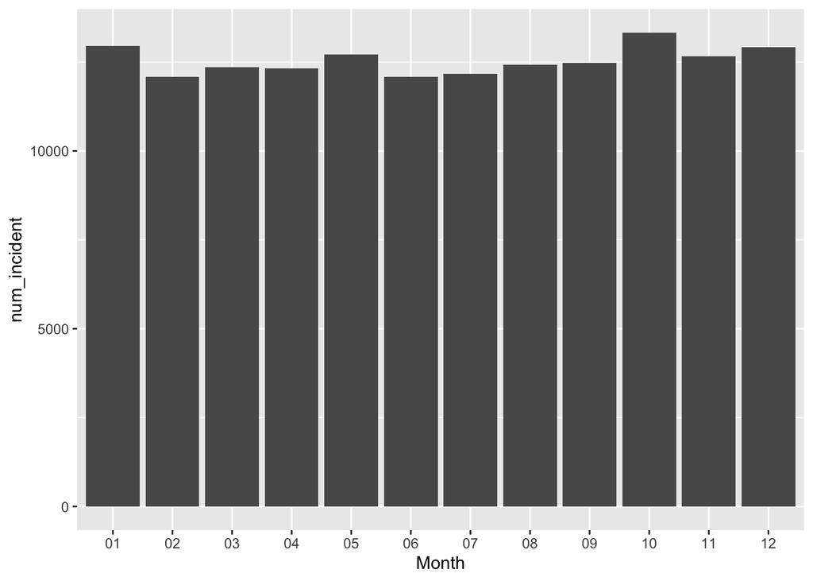

```r
tidy %>%
  group_by(Month)%>%
  summarize(num_incident = n()) %>%
  ggplot(mapping = aes(x = Month, y = num_incident)) + geom_bar(stat = "identity")
```

- Second, let’s look the crime distribution in time(by hours):

```r
table(tidy$hour)
```

```
##
##    0    1    2    3    4    5    6    7    8    9   10   11   12   13   14   15
## 6941 4359 3494 2553 1885 1744 2518 3894 5575 5865 6483 6786 9021 7268 7621 8329
##   16   17   18   19   20   21   22   23
## 8656 9559 9718 8981 8098 7480 7099 6573
```

we could also use a bar graph to see the crime distribution of all crimes in hours. As you could see from the plot and table above, in year of 2016, the least crimes commited in time period of 05:00 - 05:59 and the most crimes commited in time period of 18:00 - 18:59. Baseing on boxplot, we could see that the peroid of 1:00 - 11:59 AM is the period that crime commited under the average value. Therefore, Police officer can have more security check ands shifts around city in time period of 12:00 - 00:59.

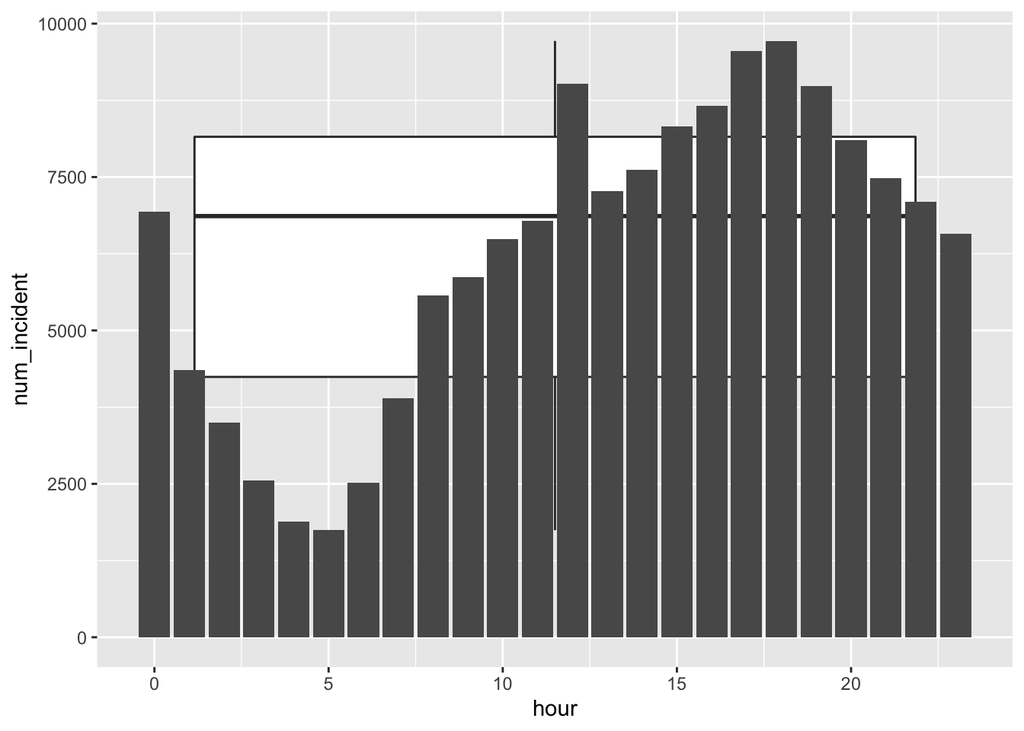

```r
tidy %>%
  group_by(hour) %>%
    summarize(num_incident = n()) %>%
  ggplot(mapping = (aes(x = hour, y = num_incident))) + geom_boxplot() + geom_bar(stat = "identity")
```

- Distribution of crimes in a week: let’s look at how crimes are distributed within a week in a year of 2016.

```r
sort(table(tidy$DayOfWeek))
```

```
##
##    Sunday    Monday   Tuesday Wednesday  Thursday  Saturday    Friday
##     20205     20783     21242     21332     21395     22172     23371
```

From the table, there is not much difference between the distribution in each day of week, and the top three days that crimes mostly commited are Friday, Saturday and Thrusday. We use bar graph to visualize the data.

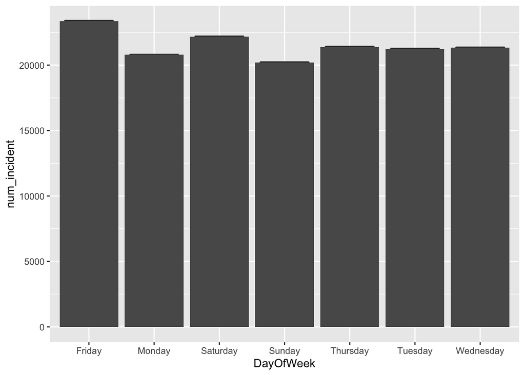

```r
tidy %>%
  group_by(DayOfWeek) %>%
    summarize(num_incident = n()) %>%
  ggplot(mapping = (aes(x = DayOfWeek, y = num_incident))) + geom_boxplot() + geom_bar(stat = "identity")
```

```r
sort(table(tidy$Category))
```

```
##
##                        TREA     PORNOGRAPHY/OBSCENE MAT
##                           3                           4
##                    GAMBLING                  BAD CHECKS
##                          20                          34
##  SEX OFFENSES, NON FORCIBLE                   LOITERING
##                          40                          42
##             FAMILY OFFENSES                   EXTORTION
##                          53                          60
##                     BRIBERY                     SUICIDE
##                          66                          69
##                     RUNAWAY                 LIQUOR LAWS
##                         140                         156
##                EMBEZZLEMENT                  KIDNAPPING
##                         168                         257
##                       ARSON DRIVING UNDER THE INFLUENCE
##                         286                         378
##                 DRUNKENNESS      FORGERY/COUNTERFEITING
##                         465                         619
##                PROSTITUTION          DISORDERLY CONDUCT
##                         641                         658
##           RECOVERED VEHICLE             STOLEN PROPERTY
##                         736                         882
##      SEX OFFENSES, FORCIBLE                 WEAPON LAWS
##                         940                        1658
##                    TRESPASS             SECONDARY CODES
##                        1812                        1841
##                       FRAUD                     ROBBERY
##                        2635                        3299
##               DRUG/NARCOTIC              MISSING PERSON
##                        4243                        4338
##              SUSPICIOUS OCC                    BURGLARY
##                        5782                        5802
##                    WARRANTS               VEHICLE THEFT
##                        5914                        6419
##                   VANDALISM                     ASSAULT
##                        8589                       13577
##                NON-CRIMINAL              OTHER OFFENSES
##                       17866                       19599
##               LARCENY/THEFT
##                       40409
```

By looking at the table of categories, the top three crimes commited in San Franciso are LARCENY/THEFT, OTHER OFFENSES and NON-CRIMINAL. A good way to do visualize is to build up a pie chart, then we could see the proportion and differences among all categories. As you could see the largest proportion LARCENY/THEFT is more than a quarter.

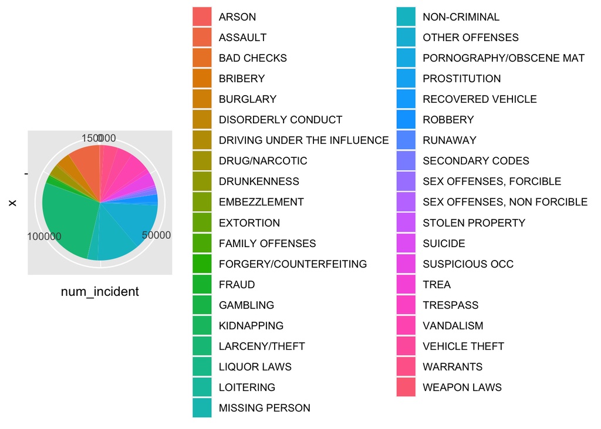

```r
tidy %>%
  group_by(Category) %>%
  summarize(num_incident = n()) %>%
  ggplot(aes(x="", y=num_incident, fill=Category)) +
  geom_bar(stat="identity", width=1) +
  coord_polar("y", start=0)
```

## Exploratory Data Analysis

A useful visualization is for geographic data is using the interactive map. Each incident has a location coordinates which let us able to see the distribution of crime incidents in San Francisco for our data.

First, we set the map view using the latitudes and longitudes of San Francisco:

```r
map <- leaflet(tidy) %>%
  addTiles() %>%
  setView(lat=37.773972, lng=-122.431297, zoom=11)
map
```

[interactive chart not shown]

[output not shown]